# Use Case “Insurance SCR” - Main effects

## 2.7 Variance allocation according to the Shapley algorithm

A well known way to allocate contributions to each member of a set is the marginal principle and its generalisation the Shapley algorithm. To apply this principle one needs to specify three items:

1. The members which shall receive the allocations,
2. An overall amount which is to be allocated to each member
3. A value function, which distributes the overall amount to the members.

where $MM$ denotes the response of the model calibrated using the first $kk$ respective $k+1k+1$ inputs. An attribution just based on these marginal increases will depend on the sequence of variables which does not make sense, since this sequence is completely arbitrary. To fix this, the Shapley algorithm simply computes increases for all possible permutations and finally averages over them. Observe, that for each permutation the sum of its marginal increases always adds up to the variance of the full model. Accordingly the mean does this as well, so attribution by the Shapley algorithm is additive.

As a simple demonstration the allocation for the four variables $x1,x2,x3,x7x1,x2,x3,x7$ making up the $zz$.block from Section 2.6.1 is programmed below.

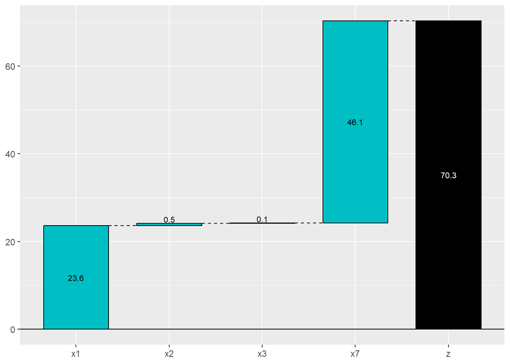

```r
# the required permutations
pm = permutations(length(idx_c), length(idx_c), idx_c)
nperm = dim(pm)[1]
nc = dim(pm)[2]

erg_ss = array(0, dim = dim(pm), dimnames = NULL)
colnames(zblock) = "zblock"
# fit models sequentially for each permutation
# step through all permutations
for(iperm in 1:nperm){
  idx = pm[iperm,]
  df = as.data.frame(cbind(zblock,x[,idx]))
  # sequential model fit, step through all variables in sequence of permutation
  for(ii in 1:nc){
    md_tmp = lm( zblock ~ ., df[,c(1,1 + (1:ii))])
    # remember variance for this group
    erg_ss[iperm, ii] = var(md_tmp$fitted.values)
  }
}

# calculate increase in variance
# prepend term with no variables, i.e. constant having zero sum of squares
erg_ss = cbind(rep(0, nperm), erg_ss)
# difference per row, i.e. increase of sum of squares due to new variable
inc_ss = t(diff(t(erg_ss)))
# relate increments to variables and aggregate all pertaining to one variable
df_tmp = data.frame(variable=c(pm), inc_ss = c(inc_ss))
tmp = aggregate(inc_ss ~ variable, df_tmp, sum)
# normalise
val_lgm = tmp$inc_ss / nperm / c(var(zblock))

df = data.frame(values = round(c(val_lgm * c(var(zblock)) / var_y) * 100,1),
                labels=c(nm_x[idx_c]) )
print(waterfall( df, calc_total = TRUE, total_axis_text = "z"))
```

This chart corresponds directly to the chart 2.6 where correlation was not distributed.

Due to being an average contribution, the amounts attributed by the Shapley algorithm may be somewhat less intuitive than directly attributed amounts. But Shapley values are always non-negative, add up to the whole amount, no matter the dependence and are uniquely defined by a set of axioms. See [Molnar] Section [9.5.3.1](https://christophm.github.io/interpretable-ml-book/shapley.html#the-shapley-value)[^4] or (Grömping (2007)) for a discussion in the context of variance attribution for linear models. But the Shapley algorithm has also been criticised and may produce counterintuitive results (see (Kumar et al. (2020))).

Note also that we had to recalibrate the model for each subset (in line 15 of the prior code block). In that sense the method would not qualify as completely “model-agnostic”. In practice this is not a restriction for the linear model as it can be quickly calibrated without manual intervention.

The pedestrian approach above is woefully inefficient, which is why it was only demonstrated for four of the variables. With more efficient programming, larger numbers of variables can be handled. That said, the algorithm requires a runtime proportional to $2d2d$, i.e. exponential time. For the Use Case the number of variables is $d=d=$ 13 which is small enough to be no problem, as is demonstrated below by a computation for all variables using the package `sensitivity`.

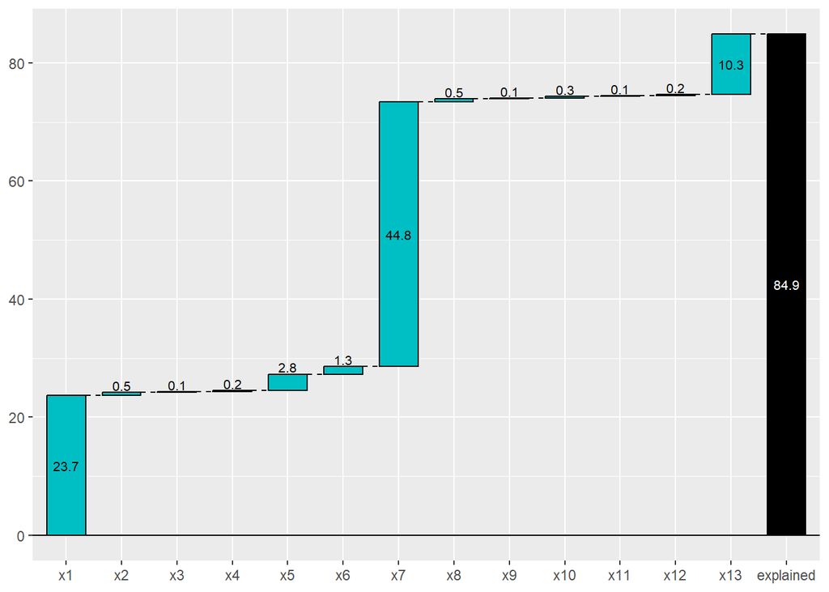

```r
tt = lmg(x, y)
df = data.frame(values = round(c(tt$lmg) * 100,1),
                labels=c(nm_x) )
print(waterfall( df, calc_total = TRUE, total_axis_text = "explained"))
```

# References

Grömping, Ulrike. 2007. “Estimators of Relative Importance in Linear Regression Based on Variance Decomposition.” *The American Statistician* 61: 139–47. https://prof.beuth-hochschule.de/fileadmin/prof/groemp/downloads/amstat07mayp139.pdf.

Hooker, Giles, Lucas Mentch, and Siyu Zhou. 2021. “Unrestricted Permutation Forces Extrapolation: Variable Importance Requires at Least One More Model, or There Is No Free Variable Importance.” *Statistics and Computing* 31 (6). https://doi.org/10.1007/s11222-021-10057-z.

Kopinsky, M. 2017. “Predicting Group Long Term Disability Recovery and Mortality Rates Using Tree Models.” https://www.soa.org/experience-studies/2017/2017-gltd-recovery-mortality-tree/.

Kumar, I. Elizabeth, Suresh Venkatasubramanian, Carlos Scheidegger, and Sorelle A. Friedler. 2020. “Problems with Shapley-Value-Based Explanations as Feature Importance Measures.” In *Proceedings of the 37th International Conference on Machine Learning*. ICML’20. JMLR.org.

[^1]: Note that this joint distribution of the input variables seems to contradict the statements found in the section “Underlying data set” in the use case description.
[^2]: Indeed it is well known that these errors are in general heteroskedastic. Furthermore, often certain shortcuts in the generation of the inner scenarios are employed to increase speed. Typical examples are antithetic variables or the shift algorithm for the initial yield curve. These shortcuts may create complicated dependencies between errors at different outer scenarios. Unfortunately this is not covered in the use case description. While the use case provides additional data on error variance, this is not available for the base scenarios considered here.
[^3]: These issues often seem to be largely ignored by practitioners. See for example the discussion of variable importance for the disability use case in the original report (Kopinsky (2017)). In the regression context these problems have been known and discussed for decades. The Machine Learning community apparently rediscovered them recently (Hooker, Mentch, and Zhou (2021)).
[^4]: What he describes as “Shapley values” is different from the definition used here. He does not distinguish between the value and the algorithm for allocation and uses a different value but his general statements mostly remain valid and apply to the situation here.